# Nashville Excercise 1

Grant Rhines

2022-01-07

## Post Match Analysis

##### Nashville SC vs. Orlando City SC – Nov. 23rd, 2021

As demonstrated by [Statbomb’s (via FBRef)](https://fbref.com/en/matches/edd92a6d/Nashville-SC-Orlando-City-November-23-2021-Major-League-Soccer) and [FootyStat’s](https://footystats.org/usa/orlando-city-sc-vs-nashville-sc-mls-h2h-stats#1448602) assessment of the match, it is clear that Nashville scarcely deserved to win the game:

[figure not shown]

FBRef

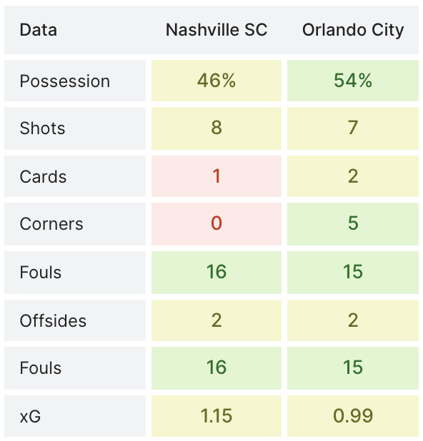

FootyStats

Furthermore, [SofaScore’s Attacking Momentum](https://www.sofascore.com/news/sofascore-attack-momentum/) graphic gives us a deeper look into each team’s performance.

[interactive chart not shown]

[Nashville SC - Orlando City SC Live Score](https://www.sofascore.com/orlando-city-sc-nashville-sc/MUvsmcKc)

Specifically, Orlando was able to dominate the majority of the match and were very unfortunate not to score in their pushes in the 60<sup>th</sup> and 80<sup>th</sup> minute. In Nashville’s favor, the several sudden, large spikes in momentum tell us **the team’s counter-attacking strategy was resulting in quality chances**.

The Attack Momentum graphic also gives us some quality insights into the impact each team’s substitutions were able to make. While Orlando’s late substitutions effectively reinvigorated their attack, **Nashville’s mostly offensive changes did little to stop the flood of Orlando pressure came in the second half**. In hindsight, it may have been a better decision to bring on Taylor Washington rather than Tah Anunga.

Next, here are a few [statistics provided by SofaScore (via Opta)](https://www.sofascore.com/team/football/nashville-sc/337612) that demonstrate the solid defensive performance Nashville’s back line displayed by significantly limiting the opportunities that were being created from the many Orlando attacks. Despite taking five shots within Nashville’s penalty box, none of them were deemed as “big chances”.

[figure not shown]

SofaScore

All in all, **Nashville consistently absorbed their opponent’s pressure to create lethal counter-attacking opportunities, but struggled to convert the high-quality chances they produced into dangerous shots**.

=========================================================================================================

## Phil. Union Opposition Report

### Team-level Insights

Below is every match that Philadelphia Union played during the 2021 MLS season:

2021 Philadelphia Union Schedule

| Date | Round | Venue | Result | GF | GA | Opponent | xG | xGA | Formation |
| --- | --- | --- | --- | --- | --- | --- | --- | --- | --- |
| 2021-04-18 | Regular Season | Away | D | 0 | 0 | Columbus Crew | 1.2 | 1.5 | 4-4-2◆ |
| 2021-04-24 | Regular Season | Home | L | 1 | 2 | Inter Miami | 1.1 | 0.9 | 4-4-2◆ |
| 2021-05-01 | Regular Season | Home | L | 0 | 2 | NYCFC | 0.2 | 2.6 | 4-4-2◆ |
| 2021-05-08 | Regular Season | Away | W | 2 | 0 | Chicago Fire | 1.7 | 1.0 | 4-4-2◆ |
| 2021-05-12 | Regular Season | Home | D | 1 | 1 | New England | 2.1 | 1.4 | 4-4-2◆ |
| 2021-05-15 | Regular Season | Home | W | 1 | 0 | NY Red Bulls | 1.5 | 1.2 | 4-4-2◆ |
| 2021-05-23 | Regular Season | Away | W | 1 | 0 | D.C. United | 1.0 | 1.4 | 4-4-2◆ |
| 2021-05-30 | Regular Season | Home | W | 3 | 0 | Portland Timbers | 2.7 | 1.2 | 4-4-2◆ |
| 2021-06-20 | Regular Season | Away | D | 2 | 2 | Atlanta Utd | 2.1 | 0.9 | 4-4-2◆ |
| 2021-06-23 | Regular Season | Home | W | 1 | 0 | Columbus Crew | 0.4 | 0.6 | 4-4-2◆ |
| 2021-06-26 | Regular Season | Away | D | 3 | 3 | Chicago Fire | 1.1 | 1.1 | 4-4-2◆ |
| 2021-07-03 | Regular Season | Away | L | 0 | 1 | Nashville | 0.9 | 1.3 | 4-4-2◆ |
| 2021-07-08 | Regular Season | Away | D | 1 | 1 | NY Red Bulls | 1.0 | 2.0 | 4-4-2◆ |
| 2021-07-17 | Regular Season | Home | W | 2 | 1 | D.C. United | 1.6 | 1.4 | 4-4-2◆ |
| 2021-07-22 | Regular Season | Away | L | 1 | 2 | Orlando City | 1.3 | 0.9 | 4-4-2◆ |
| 2021-07-25 | Regular Season | Away | D | 1 | 1 | Inter Miami | 1.5 | 1.0 | 4-3-2-1 |
| 2021-08-01 | Regular Season | Home | D | 1 | 1 | Chicago Fire | 2.0 | 0.2 | 4-3-2-1 |
| 2021-08-04 | Regular Season | Home | W | 3 | 0 | Toronto FC | 2.4 | 1.4 | 4-3-2-1 |
| 2021-08-08 | Regular Season | Away | L | 1 | 2 | New England | 1.3 | 2.7 | 3-4-3 |
| 2021-08-18 | Regular Season | Home | W | 1 | 0 | NYCFC | 0.5 | 0.9 | 4-4-2◆ |
| 2021-08-21 | Regular Season | Home | D | 1 | 1 | CF Montréal | 1.1 | 1.0 | 4-4-2◆ |
| 2021-08-28 | Regular Season | Away | L | 1 | 3 | D.C. United | 0.4 | 2.8 | 4-4-2◆ |
| 2021-09-03 | Regular Season | Home | L | 0 | 1 | New England | 0.7 | 1.0 | 4-2-3-1 |
| 2021-09-19 | Regular Season | Home | W | 3 | 1 | Orlando City | 2.1 | 0.6 | 4-4-2◆ |
| 2021-09-25 | Regular Season | Home | W | 1 | 0 | Atlanta Utd | 1.3 | 0.2 | 4-4-2◆ |
| 2021-09-29 | Regular Season | Away | D | 1 | 1 | NY Red Bulls | 0.9 | 0.7 | 4-4-2◆ |
| 2021-10-03 | Regular Season | Home | W | 3 | 0 | Columbus Crew | 1.2 | 1.6 | 4-4-2◆ |
| 2021-10-09 | Regular Season | Away | W | 2 | 1 | FC Cincinnati | 1.6 | 1.6 | 3-4-1-2 |
| 2021-10-16 | Regular Season | Away | D | 2 | 2 | CF Montréal | 0.2 | 0.6 | 4-4-2◆ |
| 2021-10-20 | Regular Season | Away | L | 2 | 3 | Minnesota Utd | 2.2 | 1.8 | 4-1-4-1 |
| 2021-10-23 | Regular Season | Home | W | 1 | 0 | Nashville | 1.6 | 0.3 | 4-3-3 |
| 2021-10-27 | Regular Season | Away | D | 2 | 2 | Toronto FC | 2.0 | 1.3 | 4-3-3 |
| 2021-10-31 | Regular Season | Home | W | 2 | 0 | FC Cincinnati | 2.5 | 0.4 | 4-3-3 |
| 2021-11-07 | Regular Season | Away | D | 1 | 1 | NYCFC | 1.8 | 0.5 | 4-4-2◆ |
| 2021-11-20 | First round | Home | W | 1 | 0 | NY Red Bulls | 2.1 | 0.9 | 4-3-2-1 |
| 2021-11-28 | Conference semifinals | Home | D | 1 (2) | 1 (0) | Nashville | 2.3 | 1.0 | 4-3-2-1 |
| 2021-12-05 | Conference finals | Home | L | 1 | 2 | NYCFC | 0.4 | 1.4 | 4-3-2-1 |

Interestingly, Nashville SC has only ever played Union three times. When playing with two strikers up front, Nashville got just one point from two games. When playing with only one striker against Philadelphia, Nashville won the game comfortably. **So, it would appear the team should favor playing with a single striker rather than a partnership**, but obviously the sample sizes behind that analysis are ridiculously low to trust its conclusion.

To get more robust results, I analyzed a custom data set that I assembled from [FBRef](https://fbref.com/en/squads/46024eeb/Philadelphia-Union-Stats) (a sample of which is shown below) and performed an [Ordinary Least Squares Regression with Robust Standard Errors](https://www.rdocumentation.org/packages/estimatr/versions/0.30.4/topics/lm_robust) to evaluate the effect that a team’s choice of formation against Union’s 4-4-2◆ had on their chances of success.

##### **Relevant Variables**

- **xGD:** tells us the difference between the xG for and xG against for a given match. A value above 0 suggests Union outperformed their opponent, while negative values tell us Philadelphia should have been beaten.
- **OppoF2:** a dummy variable that denotes whether Union’s opposition played with a front two or not.
- **OppoW:** a dummy variable that tells us if Union’s opposition chose to play with wingers or not.
- **OppoTotalxGD/90:** the opposition’s total xG Differential Per 90 Minutes that each team had achieved at the end of the season. This metric was included as a way to quantify the overall quality of each opponent Union faced and was held constant in our regression analysis.

| Date | Venue | Result | GF | GA | Opponent | xG | xGA | xGD | Formation | OppoF2 | OppoW | OppoTotalxGD/90 |
| --- | --- | --- | --- | --- | --- | --- | --- | --- | --- | --- | --- | --- |
| 44304 | Away | D | 0 | 0 | Columbus Crew | 1.2 | 1.5 | -0.3 | 4-4-2◆ | 0 | 1 | -0.12 |
| 44310 | Home | L | 1 | 2 | Inter Miami | 1.1 | 0.9 | 0.2 | 4-4-2◆ | 0 | 1 | -0.50 |
| 44317 | Home | L | 0 | 2 | NYCFC | 0.2 | 2.6 | -2.4 | 4-4-2◆ | 1 | 0 | 0.67 |
| 44324 | Away | W | 2 | 0 | Chicago Fire | 1.7 | 1.0 | 0.7 | 4-4-2◆ | 0 | 1 | -0.28 |
| 44328 | Home | D | 1 | 1 | New England | 2.1 | 1.4 | 0.7 | 4-4-2◆ | 0 | 1 | 0.36 |
| 44331 | Home | W | 1 | 0 | NY Red Bulls | 1.5 | 1.2 | 0.3 | 4-4-2◆ | 1 | 0 | 0.22 |

```r
set.seed(0)

#Fitting the model
obj <- lm_robust(xGD ~ 0 + OppoF2 + OppoW + `OppoTotalxGD/90`, data = union_formation_data)

#Presenting the model's coefficients
summary(obj)
```

```
##
## Call:
## lm_robust(formula = xGD ~ 0 + OppoF2 + OppoW + `OppoTotalxGD/90`,
##     data = union_formation_data)
##
## Standard error type:  HC2
##
## Coefficients:
##                   Estimate Std. Error t value Pr(>|t|) CI Lower CI Upper DF
## OppoF2              0.3519     0.2505   1.405  0.16450 -0.14776   0.8516 69
## OppoW               0.2576     0.1464   1.759  0.08303 -0.03457   0.5497 69
## `OppoTotalxGD/90`  -0.7478     0.4364  -1.713  0.09114 -1.61843   0.1229 69
##
## Multiple R-squared:  0.1425 ,    Adjusted R-squared:  0.1052
## F-statistic: 3.628 on 3 and 69 DF,  p-value: 0.0171
```

#### Takeaways

With those observations in mind, this analysis tells us that **if Nashville SC is fielding a comparable squad to Philadelphia Union, the team would likely be better off playing a single striker in attack rather than playing with their 3-5-2 formation.** At the very least, this analysis could be very useful to start a conversation with the coaching staff and performance analysts.

### Individual-level Insights

To find insights on the individual-level for Nashville’s next match against Philadelphia Union, I used [American Soccer Analysis’ (ASA) Goals Added](https://www.americansocceranalysis.com/what-are-goals-added) metric to identify the most integral players to Union’s play-making and goal scoring.

2021 Philadelphia Union Passing Goals Added

|  | Player | Position | Minutes | Passing Goals Added/90 | Percentile |
| --- | --- | --- | --- | --- | --- |
| 106 | Jack Elliott | CB | 3289 | 0.06 | 83 |
| 209 | Kai Wagner | FB | 3139 | 0.06 | 83 |
| 341 | Olivier Mbaizo | FB | 2729 | 0.06 | 83 |
| 214 | Jakob Glesnes | CB | 3385 | 0.05 | 76 |
| 378 | José Andrés Martínez | DM | 2155 | 0.04 | 65 |
| 188 | Jamiro Monteiro | AM | 2521 | 0.03 | 59 |
| 141 | Alejandro Bedoya | CM | 2891 | 0.01 | 42 |
| 580 | Leon Flach | CM | 2889 | -0.03 | 19 |
| 255 | Daniel Gazdag | AM | 1445 | -0.04 | 14 |
| 258 | Kacper Przybylko | ST | 2923 | -0.07 | 5 |
| 25 | Sergio Santos | ST | 1485 | -0.10 | 2 |

2021 Philadelphia Union Shooting Goals Added

|  | Player | Position | Minutes | Shooting Goals Added/90 | Percentile |
| --- | --- | --- | --- | --- | --- |
| 25 | Sergio Santos | ST | 1485 | 0.09 | 94 |
| 255 | Daniel Gazdag | AM | 1445 | 0.06 | 80 |
| 258 | Kacper Przybylko | ST | 2923 | 0.06 | 80 |
| 188 | Jamiro Monteiro | AM | 2521 | 0.04 | 66 |
| 141 | Alejandro Bedoya | CM | 2891 | 0.03 | 57 |
| 106 | Jack Elliott | CB | 3289 | 0.02 | 44 |
| 209 | Kai Wagner | FB | 3139 | 0.02 | 44 |
| 214 | Jakob Glesnes | CB | 3385 | 0.01 | 17 |
| 378 | José Andrés Martínez | DM | 2155 | 0.01 | 17 |
| 580 | Leon Flach | CM | 2889 | 0.01 | 17 |
| 341 | Olivier Mbaizo | FB | 2729 | 0.00 | 0 |

#### Takeaways

- By focusing the team’s defensive efforts on stopping Jack Elliott, Kai Wagner, Oliver Mbaizo, and Jakob Glesnes from making key passes from their own defensive third, Nashville will be able stop Philadelphia from building out of the back; a key piece of their offensive strategy.
- Though Sergio Santos and Kacper Przybylko are fantastic shooters for Union, they are amongst the worst passers in the league. If Nashville SC’s defense can force them to be the playmakers for Monteiro and Bedoya, Philadelphia’s attack would suffer enormously.

=========================================================================================================

## Phil. Union Set-Piece Analysis

To get a general idea of Philadelphia’s behavior during set-pieces, I used [ASA’s xGoal](https://app.americansocceranalysis.com/#!/mls/xgoals/teams) data to analyze each team’s non-corner set-piece and corner kick performances **in terms of efficiency and frequency** in relation to other MLS teams. Those results shown below:

2021 MLS Set-piece Totals (Ranked By Frequency)

| Rank | Team | xGF | FK | xGF/FK |
| --- | --- | --- | --- | --- |
| 16 | POR | 4.25 | 42 | 0.10 |
| 17 | RSL | 2.73 | 40 | 0.07 |
| 18 | PHI | 2.57 | 39 | 0.07 |
| 19 | LAG | 2.60 | 38 | 0.07 |
| 20 | HOU | 2.07 | 37 | 0.06 |

2021 MLS Corner Totals (Ranked By Efficiency)

| Rank | Team | xGF | CK | xGF/CK |
| --- | --- | --- | --- | --- |
| 1 | PHI | 7.50 | 84 | 0.09 |
| 2 | LAG | 6.49 | 79 | 0.08 |
| 3 | LAFC | 5.96 | 73 | 0.08 |
| 4 | SJE | 6.86 | 86 | 0.08 |
| 5 | MIN | 5.60 | 71 | 0.08 |

In terms of non-corner set-pieces, Union performed very poorly. The team ranked 24<sup>th</sup> of 27<sup>th</sup> in xG per shot during the 2021 MLS season. If they have not improved their approach since last season, they will pose very little threat in 2022.

Additionally, Philadelphia seldom chooses to shoot the ball. In fact, **Union shoots from set-pieces 25% less than LAFC, who led the league in shots from free-kicks**. Instead, **Philadelphia generally chooses to use their free kicks as opportunities to set up subsequent chances that might prove to be more valuable**.

Ironically, **Union were the most productive scorers from corner kicks during the 2021 MLS season**; producing 29% more xG per attempt than the league average.

#### Takeaways

- Nashville should focus on defending against dangerous passes rather than blocking shots while defending Philadelphia’s non-corner set-pieces. If Nashville is able to reliably regain possession from Union, the team should set up to take advantage of potential counter attacking opportunities.
- Philadelphia’s corner kicks should be met with “no-nonsense” defending and be cleared rather than trying to played.